# Regularization Examples

W. Evan Johnson, Ph.D. Professor, Division of Infectious Disease Director, Center for Data Science Rutgers University – New Jersey Medical School

10/2/2023

# Regularization Data Examples

## Salary dataset

A researcher wants to determine how employee salaries at a certain company are related to the length of employment, previous experience, and education. The researcher selects eight employees from the company and obtains the data shown below.

```r
salary <- tibble(
    Salary = c(57310.00, 57380.00, 54135.00, 56985.00, 58715.00, 60620.00, 59200.00, 60320.00),
    Employment = c(10,5,3,6,8,20,8,14),
    Experience = c(2,6,1,5,8,0,4,6),
    Education = c(16,16,12,14,16,12,18,17)
)

datatable(salary)
```

|  | Salary | Employment | Experience | Education |
| --- | --- | --- | --- | --- |
| 1 | 57310 | 10 | 2 | 16 |
| 2 | 57380 | 5 | 6 | 16 |
| 3 | 54135 | 3 | 1 | 12 |
| 4 | 56985 | 6 | 5 | 14 |
| 5 | 58715 | 8 | 8 | 16 |
| 6 | 60620 | 20 | 0 | 12 |
| 7 | 59200 | 8 | 4 | 18 |
| 8 | 60320 | 14 | 6 | 17 |

### LASSO

```r
fit <- glmnet(salary[,-1], salary$Salary)
```

#### Visualize L1

We can visualize the coefficients by executing the plot method:

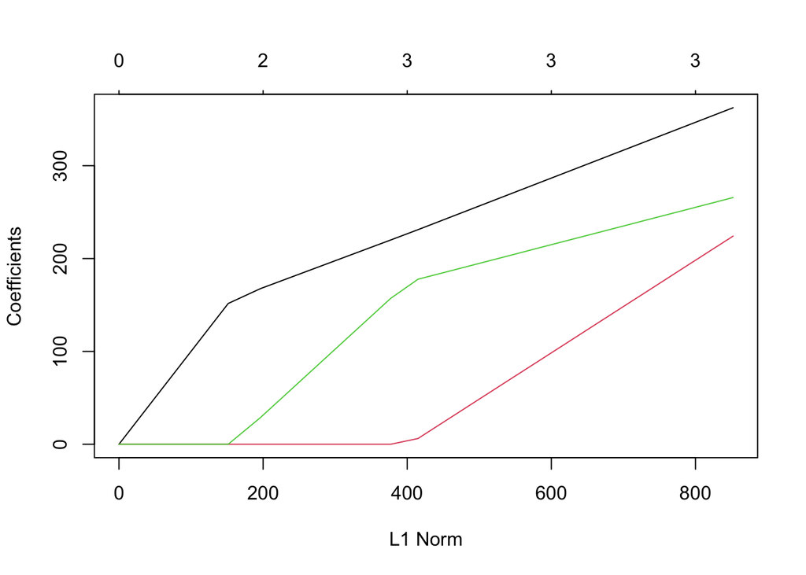

```r
plot(fit)
```

#### Print summary

A summary of the glmnet path at each step is displayed if we just enter the object name or use the print function:

```r
print(fit)
```

```
##
## Call:  glmnet(x = salary[, -1], y = salary$Salary)
##
##    Df  %Dev  Lambda
## 1   0  0.00 1621.00
## 2   1 11.52 1477.00
## 3   1 21.09 1346.00
## 4   1 29.03 1226.00
## 5   1 35.63 1117.00
## 6   1 41.10 1018.00
## 7   1 45.65  927.60
## 8   1 49.42  845.20
## 9   2 55.28  770.10
## 10  2 61.11  701.70
## 11  2 65.96  639.40
```

[output cut: 48 more lines]

#### Results for various $\lambda$s

##### Results $\lambda = 1000$:

```r
coef(fit, s = 1000)
```

```
## 4 x 1 sparse Matrix of class "dgCMatrix"
##                     s1
## (Intercept) 56960.5516
## Employment    121.3593
## Experience      .
## Education       .
```

##### Results $\lambda = 800$:

```r
coef(fit, s = 800)
```

```
## 4 x 1 sparse Matrix of class "dgCMatrix"
##                     s1
## (Intercept) 56331.3787
## Employment    161.2026
## Experience      .
## Education      17.2312
```

##### Results $\lambda=500$

```r
coef(fit, s = 500)
```

```
## 4 x 1 sparse Matrix of class "dgCMatrix"
##                       s1
## (Intercept) 53384.924181
## Employment    227.235795
## Experience      4.032595
## Education     170.587724
```

##### Results $\lambda=1$

```r
coef(fit, s = 1)
```

```
## 4 x 1 sparse Matrix of class "dgCMatrix"
##                     s1
## (Intercept) 49816.5511
## Employment    362.3777
## Experience    224.1650
## Education     265.6476
```

### Ridge Regression

```r
fit <- glmnet(salary[,-1], salary$Salary, alpha=0)
```

#### Visualize L1

We can visualize the coefficients by executing the plot method:

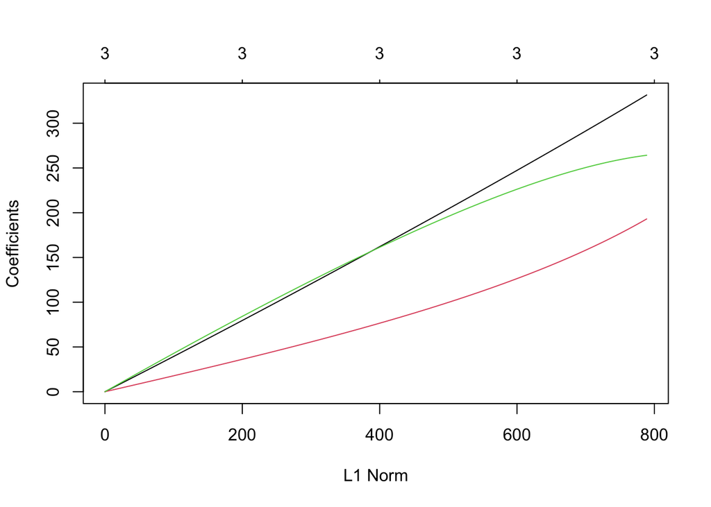

```r
plot(fit)
```

#### Print summary

A summary of the glmnet path at each step is displayed if we just enter the object name or use the print function:

```r
print(fit)
```

```
##
## Call:  glmnet(x = salary[, -1], y = salary$Salary, alpha = 0)
##
##     Df  %Dev  Lambda
## 1    3  0.00 1621000
## 2    3  0.23 1477000
## 3    3  0.25 1346000
## 4    3  0.27 1226000
## 5    3  0.30 1117000
## 6    3  0.33 1018000
## 7    3  0.36  927600
## 8    3  0.40  845200
## 9    3  0.44  770100
## 10   3  0.48  701700
## 11   3  0.52  639400
```

[output cut: 89 more lines]

#### Results for various $\lambda$s

##### Results $\lambda = 1000$:

```r
coef(fit, s = 1000)
```

```
## 4 x 1 sparse Matrix of class "dgCMatrix"
##                     s1
## (Intercept) 52286.1816
## Employment    228.2634
## Experience    114.1708
## Education     213.4759
```

##### Results $\lambda = 800$:

```r
coef(fit, s = 800)
```

```
## 4 x 1 sparse Matrix of class "dgCMatrix"
##                     s1
## (Intercept) 51887.5540
## Employment    246.4046
## Experience    125.7878
## Education     225.6646
```

##### Results $\lambda=500$

```r
coef(fit, s = 500)
```

```
## 4 x 1 sparse Matrix of class "dgCMatrix"
##                     s1
## (Intercept) 51188.9455
## Employment    279.9939
## Experience    149.4185
## Education     245.0619
```

##### Results $\lambda=1$

```r
coef(fit, s = 1)
```

```
## 4 x 1 sparse Matrix of class "dgCMatrix"
##                     s1
## (Intercept) 50248.1355
## Employment    331.5340
## Experience    193.0441
## Education     264.2065
```

### Elastic Net

```r
fit <- glmnet(salary[,-1], salary$Salary, alpha=0.5)
```

#### Visualize L1

We can visualize the coefficients by executing the plot method:

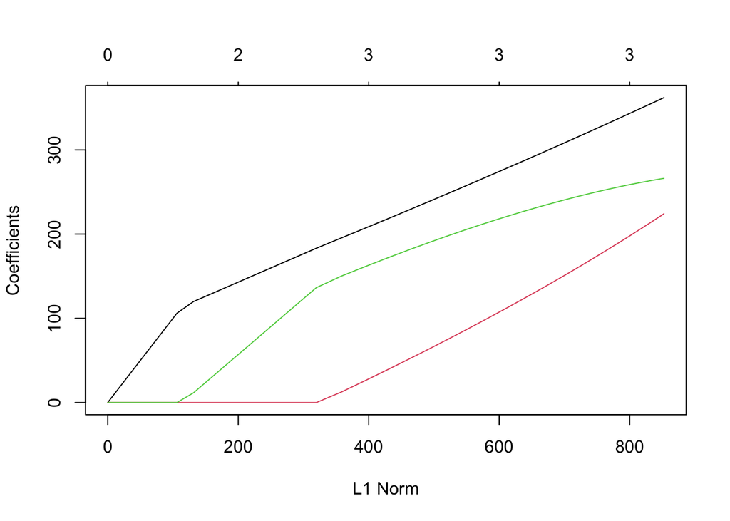

```r
plot(fit)
```

#### Print summary

A summary of the glmnet path at each step is displayed if we just enter the object name or use the print function:

```r
print(fit)
```

```
##
## Call:  glmnet(x = salary[, -1], y = salary$Salary, alpha = 0.5)
##
##    Df  %Dev Lambda
## 1   0  0.00 3242.0
## 2   1  6.71 2954.0
## 3   1 13.00 2692.0
## 4   1 18.84 2453.0
## 5   1 24.24 2235.0
## 6   1 29.20 2036.0
## 7   1 33.73 1855.0
## 8   1 37.84 1690.0
## 9   2 42.63 1540.0
## 10  2 48.41 1403.0
## 11  2 53.61 1279.0
```

[output cut: 53 more lines]

#### Results for various $\lambda$s

##### Results $\lambda = 2000$:

```r
coef(fit, s = 2000)
```

```
## 4 x 1 sparse Matrix of class "dgCMatrix"
##                      s1
## (Intercept) 57338.17728
## Employment     80.53489
## Experience      .
## Education       .
```

##### Results $\lambda = 1000$:

```r
coef(fit, s = 1000)
```

```
## 4 x 1 sparse Matrix of class "dgCMatrix"
##                     s1
## (Intercept) 54480.6474
## Employment    179.2530
## Experience      .
## Education     128.5545
```

##### Results $\lambda=500$

```r
coef(fit, s = 500)
```

```
## 4 x 1 sparse Matrix of class "dgCMatrix"
##                      s1
## (Intercept) 52237.38412
## Employment    257.94034
## Experience     86.96809
## Education     205.74680
```

##### Results $\lambda=1$

```r
coef(fit, s = 1)
```

```
## 4 x 1 sparse Matrix of class "dgCMatrix"
##                     s1
## (Intercept) 49810.4663
## Employment    362.0977
## Experience    224.2341
## Education     266.2028
```

## Car sales dataset

```r
cars <- read_csv("Car price prediction.csv")
datatable(cars)
```

|  | name | year | selling_price | km_driven | fuel | seller_type | transmission | owner |
| --- | --- | --- | --- | --- | --- | --- | --- | --- |
| 1 | Maruti 800 AC | 2007 | 60000 | 70000 | Petrol | Individual | Manual | First Owner |
| 2 | Maruti Wagon R LXI Minor | 2007 | 135000 | 50000 | Petrol | Individual | Manual | First Owner |
| 3 | Hyundai Verna 1.6 SX | 2012 | 600000 | 100000 | Diesel | Individual | Manual | First Owner |
| 4 | Datsun RediGO T Option | 2017 | 250000 | 46000 | Petrol | Individual | Manual | First Owner |
| 5 | Honda Amaze VX i-DTEC | 2014 | 450000 | 141000 | Diesel | Individual | Manual | Second Owner |
| 6 | Maruti Alto LX BSIII | 2007 | 140000 | 125000 | Petrol | Individual | Manual | First Owner |
| 7 | Hyundai Xcent 1.2 Kappa S | 2016 | 550000 | 25000 | Petrol | Individual | Manual | First Owner |
| 8 | Tata Indigo Grand Petrol | 2014 | 240000 | 60000 | Petrol | Individual | Manual | Second Owner |
| 9 | Hyundai Creta 1.6 VTVT S | 2015 | 850000 | 25000 | Petrol | Individual | Manual | First Owner |
| 10 | Maruti Celerio Green VXI | 2017 | 365000 | 78000 | CNG | Individual | Manual | First Owner |

[output cut: 4330 more lines]

### LASSO

```r
fit <- glmnet(cars[,c(2,4:8)], cars$selling_price)
```

#### Visualize L1

We can visualize the coefficients by executing the plot method:

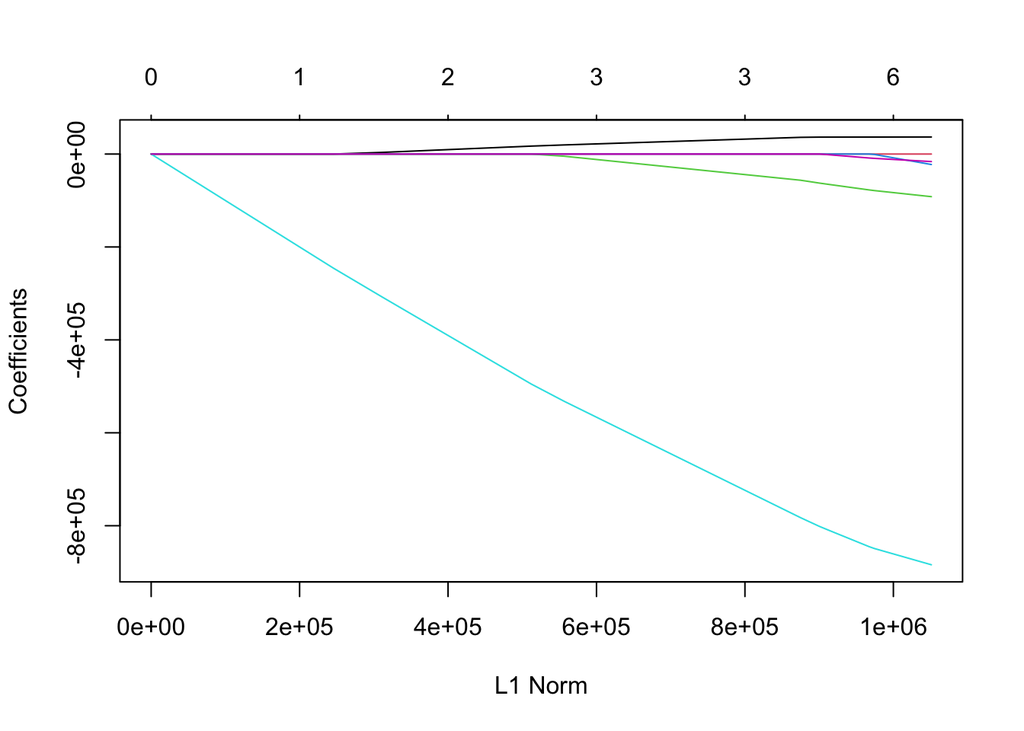

```r
plot(fit)
```

#### Print summary

A summary of the glmnet path at each step is displayed if we just enter the object name or use the print function:

```r
print(fit)
```

```
##
## Call:  glmnet(x = cars[, c(2, 4:8)], y = cars$selling_price)
##
##    Df  %Dev Lambda
## 1   0  0.00 306700
## 2   1  4.77 279500
## 3   1  8.74 254600
## 4   1 12.03 232000
## 5   2 16.40 211400
## 6   2 20.37 192600
## 7   2 23.66 175500
## 8   2 26.39 159900
## 9   2 28.66 145700
## 10  3 31.03 132800
## 11  3 33.27 121000
```

[output cut: 49 more lines]

#### Results for various $\lambda$s

##### Results $\lambda = 200,000$:

```r
coef(fit, s = 200000)
```

```
## 7 x 1 sparse Matrix of class "dgCMatrix"
##                         s1
## (Intercept)  -10606582.315
## year              5838.745
## km_driven            .
## fuel                 .
## seller_type          .
## transmission   -339109.628
## owner                .
```

##### Results $\lambda = 100,000$:

```r
coef(fit, s = 100000)
```

```
## 7 x 1 sparse Matrix of class "dgCMatrix"
##                        s1
## (Intercept)  -49756954.15
## year             25595.58
## km_driven            .
## fuel            -23599.56
## seller_type          .
## transmission   -623833.92
## owner                .
```

##### Results $\lambda=20,000$

```r
coef(fit, s = 20000)
```

```
## 7 x 1 sparse Matrix of class "dgCMatrix"
##                         s1
## (Intercept)  -7.110534e+07
## year          3.652200e+04
## km_driven    -5.535823e-01
## fuel         -7.621716e+04
## seller_type   .
## transmission -8.420376e+05
## owner        -7.918013e+03
```

##### Results $\lambda=1$

```r
coef(fit, s = 1)
```

```
## 7 x 1 sparse Matrix of class "dgCMatrix"
##                         s1
## (Intercept)  -7.122892e+07
## year          3.669089e+04
## km_driven    -9.688845e-01
## fuel         -9.172922e+04
## seller_type  -2.251864e+04
## transmission -8.840139e+05
## owner        -1.620386e+04
```

#### Cross-validation

```r
set.seed(0)
design <- cars %>% model.matrix(~fuel+seller_type+transmission+owner, data = .)
design <- cbind(year = cars$year, km_driven = cars$km_driven,design)
cvfit <- cv.glmnet(design, cars$selling_price)
```

##### Cross-validation plot

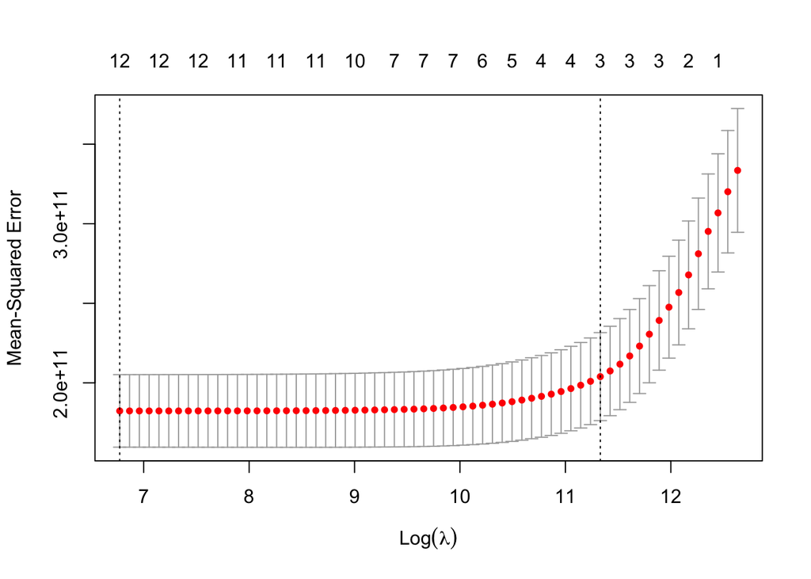

```r
plot(cvfit)
```

##### $\lambda_{min}$ value

We can get the value of $\lambda_{min}$ and the model coefficients:

```r
cvfit$lambda.min
```

```
## [1] 873.533
```

##### Coefficients at $\lambda_{min}$

```r
coef(cvfit, s = "lambda.min")
```

```
## 15 x 1 sparse Matrix of class "dgCMatrix"
##                                        s1
## (Intercept)                 -6.987052e+07
## year                         3.533916e+04
## km_driven                   -9.417784e-01
## (Intercept)                  .
## fuelDiesel                   2.771687e+05
## fuelElectric                -5.550947e+05
## fuelLPG                      2.598985e+04
## fuelPetrol                  -1.102468e+04
## seller_typeIndividual       -6.621737e+04
## seller_typeTrustmark Dealer  1.629542e+05
## transmissionManual          -8.681015e+05
## ownerFourth & Above Owner    .
## ownerSecond Owner           -3.901142e+04
## ownerTest Drive Car          1.557313e+05
## ownerThird Owner            -3.643022e+04
```

### Ridge Regression

```r
fit <- glmnet(salary[,-1], salary$Salary, alpha=0)
```

#### Visualize L1

We can visualize the coefficients by executing the plot method:

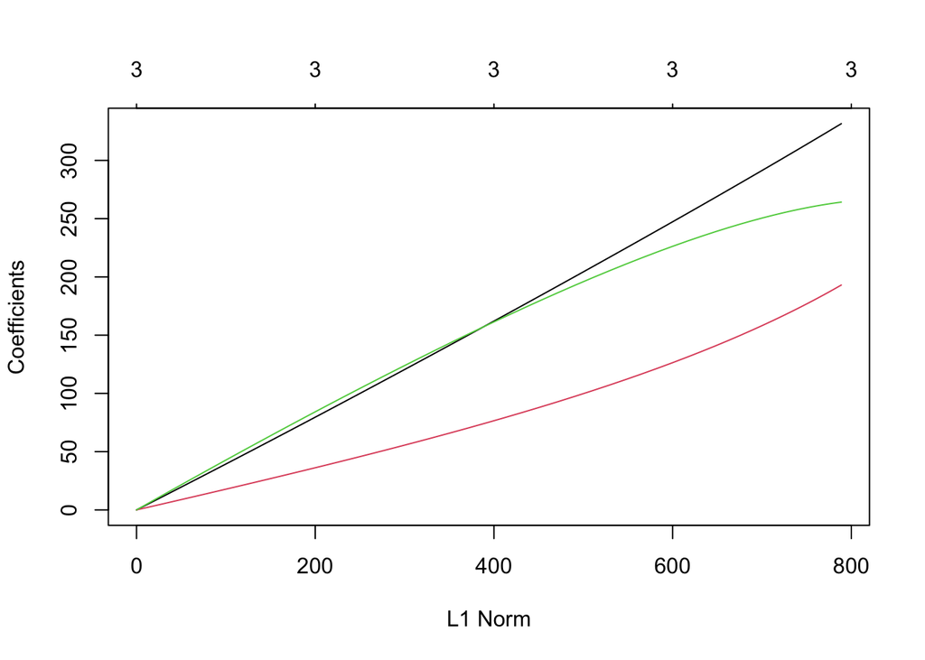

```r
plot(fit)
```

#### Print summary

A summary of the glmnet path at each step is displayed if we just enter the object name or use the print function:

```r
print(fit)
```

```
##
## Call:  glmnet(x = salary[, -1], y = salary$Salary, alpha = 0)
##
##     Df  %Dev  Lambda
## 1    3  0.00 1621000
## 2    3  0.23 1477000
## 3    3  0.25 1346000
## 4    3  0.27 1226000
## 5    3  0.30 1117000
## 6    3  0.33 1018000
## 7    3  0.36  927600
## 8    3  0.40  845200
## 9    3  0.44  770100
## 10   3  0.48  701700
## 11   3  0.52  639400
```

[output cut: 89 more lines]

#### Results for various $\lambda$s

##### Results $\lambda = 200,000$:

```r
coef(fit, s = 200000)
```

```
## 4 x 1 sparse Matrix of class "dgCMatrix"
##                       s1
## (Intercept) 57996.798686
## Employment      3.096246
## Experience      1.400386
## Education       3.443603
```

##### Results $\lambda = 100,000$:

```r
coef(fit, s = 100000)
```

```
## 4 x 1 sparse Matrix of class "dgCMatrix"
##                       s1
## (Intercept) 57912.439084
## Employment      6.129434
## Experience      2.771223
## Education       6.803554
```

##### Results $\lambda=20,000$

```r
coef(fit, s = 20000)
```

```
## 4 x 1 sparse Matrix of class "dgCMatrix"
##                      s1
## (Intercept) 57290.49942
## Employment     28.71889
## Experience     12.96884
## Education      31.41160
```

##### Results $\lambda=1$

```r
coef(fit, s = 1)
```

```
## 4 x 1 sparse Matrix of class "dgCMatrix"
##                     s1
## (Intercept) 50248.1355
## Employment    331.5340
## Experience    193.0441
## Education     264.2065
```

### Elastic Net

```r
fit <- glmnet(salary[,-1], salary$Salary, alpha=0.5)
```

#### Visualize L1

We can visualize the coefficients by executing the plot method:

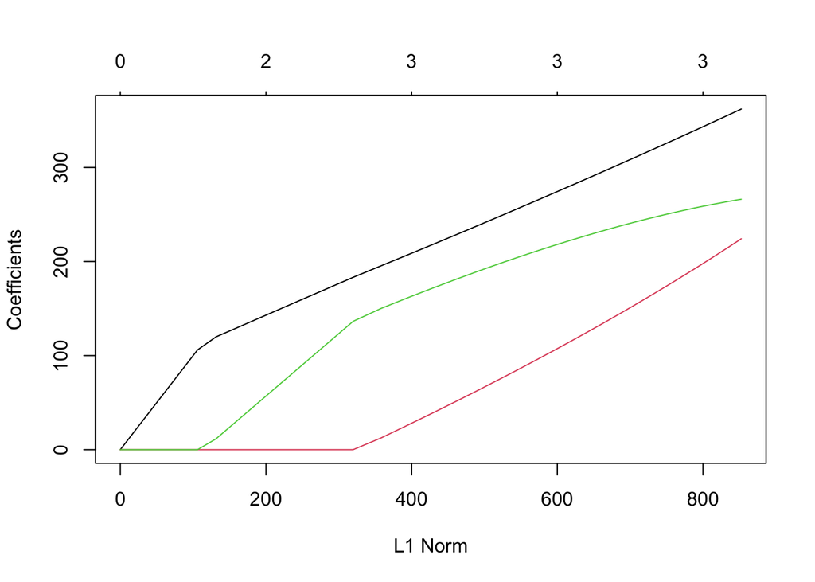

```r
plot(fit)
```

#### Print summary

A summary of the glmnet path at each step is displayed if we just enter the object name or use the print function:

```r
print(fit)
```

```
##
## Call:  glmnet(x = salary[, -1], y = salary$Salary, alpha = 0.5)
##
##    Df  %Dev Lambda
## 1   0  0.00 3242.0
## 2   1  6.71 2954.0
## 3   1 13.00 2692.0
## 4   1 18.84 2453.0
## 5   1 24.24 2235.0
## 6   1 29.20 2036.0
## 7   1 33.73 1855.0
## 8   1 37.84 1690.0
## 9   2 42.63 1540.0
## 10  2 48.41 1403.0
## 11  2 53.61 1279.0
```

[output cut: 53 more lines]

#### Results for various $\lambda$s

##### Results $\lambda = 200,000$:

```r
coef(fit, s = 200000)
```

```
## 4 x 1 sparse Matrix of class "dgCMatrix"
##                   s1
## (Intercept) 58083.12
## Employment      .
## Experience      .
## Education       .
```

##### Results $\lambda = 100,000$:

```r
coef(fit, s = 100000)
```

```
## 4 x 1 sparse Matrix of class "dgCMatrix"
##                   s1
## (Intercept) 58083.12
## Employment      .
## Experience      .
## Education       .
```

##### Results $\lambda=20,000$

```r
coef(fit, s = 20000)
```

```
## 4 x 1 sparse Matrix of class "dgCMatrix"
##                   s1
## (Intercept) 58083.12
## Employment      .
## Experience      .
## Education       .
```

##### Results $\lambda=1$

```r
coef(fit, s = 1)
```

```
## 4 x 1 sparse Matrix of class "dgCMatrix"
##                     s1
## (Intercept) 49810.4663
## Employment    362.0977
## Experience    224.2341
## Education     266.2028
```

#### Cross-validation

```r
set.seed(0)
design <- cars %>% model.matrix(~fuel+seller_type+transmission+owner, data = .)
design <- cbind(year = cars$year, km_driven = cars$km_driven,design)
cvfit <- cv.glmnet(design, cars$selling_price)
```

##### Cross-validation plot

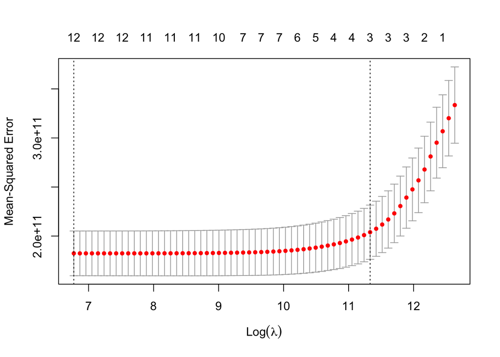

```r
plot(cvfit)
```

##### $\lambda_{min}$ value

We can get the value of $\lambda_{min}$ and the model coefficients:

```r
cvfit$lambda.min
```

```
## [1] 873.533
```

##### Coefficients at $\lambda_{min}$

```r
coef(cvfit, s = "lambda.min")
```

```
## 15 x 1 sparse Matrix of class "dgCMatrix"
##                                        s1
## (Intercept)                 -6.987052e+07
## year                         3.533916e+04
## km_driven                   -9.417784e-01
## (Intercept)                  .
## fuelDiesel                   2.771687e+05
## fuelElectric                -5.550947e+05
## fuelLPG                      2.598985e+04
## fuelPetrol                  -1.102468e+04
## seller_typeIndividual       -6.621737e+04
## seller_typeTrustmark Dealer  1.629542e+05
## transmissionManual          -8.681015e+05
## ownerFourth & Above Owner    .
## ownerSecond Owner           -3.901142e+04
## ownerTest Drive Car          1.557313e+05
## ownerThird Owner            -3.643022e+04
```

## Cereal dataset

Eat too much sugary cereal? Ruin your appetite with this dataset! If you like to eat cereal, do yourself a favor and avoid this dataset at all costs. After seeing these data it will never be the same for me to eat Fruity Pebbles again.

```r
cereal <- read_csv("cereal.csv")
datatable(cereal)
```

|  | name | mfr | type | calories | protein | fat | sodium | fiber | carbo | sugars | potass | vitamins | shelf | weight | cups | rating |
| --- | --- | --- | --- | --- | --- | --- | --- | --- | --- | --- | --- | --- | --- | --- | --- | --- |
| 1 | 100% Bran | N | C | 70 | 4 | 1 | 130 | 10 | 5 | 6 | 280 | 25 | 3 | 1 | 0.33 | 68.402973 |
| 2 | 100% Natural Bran | Q | C | 120 | 3 | 5 | 15 | 2 | 8 | 8 | 135 | 0 | 3 | 1 | 1 | 33.983679 |
| 3 | All-Bran | K | C | 70 | 4 | 1 | 260 | 9 | 7 | 5 | 320 | 25 | 3 | 1 | 0.33 | 59.425505 |
| 4 | All-Bran with Extra Fiber | K | C | 50 | 4 | 0 | 140 | 14 | 8 | 0 | 330 | 25 | 3 | 1 | 0.5 | 93.704912 |
| 5 | Almond Delight | R | C | 110 | 2 | 2 | 200 | 1 | 14 | 8 | -1 | 25 | 3 | 1 | 0.75 | 34.384843 |
| 6 | Apple Cinnamon Cheerios | G | C | 110 | 2 | 2 | 180 | 1.5 | 10.5 | 10 | 70 | 25 | 1 | 1 | 0.75 | 29.509541 |
| 7 | Apple Jacks | K | C | 110 | 2 | 0 | 125 | 1 | 11 | 14 | 30 | 25 | 2 | 1 | 1 | 33.174094 |
| 8 | Basic 4 | G | C | 130 | 3 | 2 | 210 | 2 | 18 | 8 | 100 | 25 | 3 | 1.33 | 0.75 | 37.038562 |
| 9 | Bran Chex | R | C | 90 | 2 | 1 | 200 | 4 | 15 | 6 | 125 | 25 | 1 | 1 | 0.67 | 49.120253 |
| 10 | Bran Flakes | P | C | 90 | 3 | 0 | 210 | 5 | 13 | 5 | 190 | 25 | 3 | 1 | 0.67 | 53.313813 |

[output cut: 67 more lines]

```r
fit <- glmnet(cereal[,c(2:15)], cereal$rating)
```

#### Visualize L1

We can visualize the coefficients by executing the plot method:

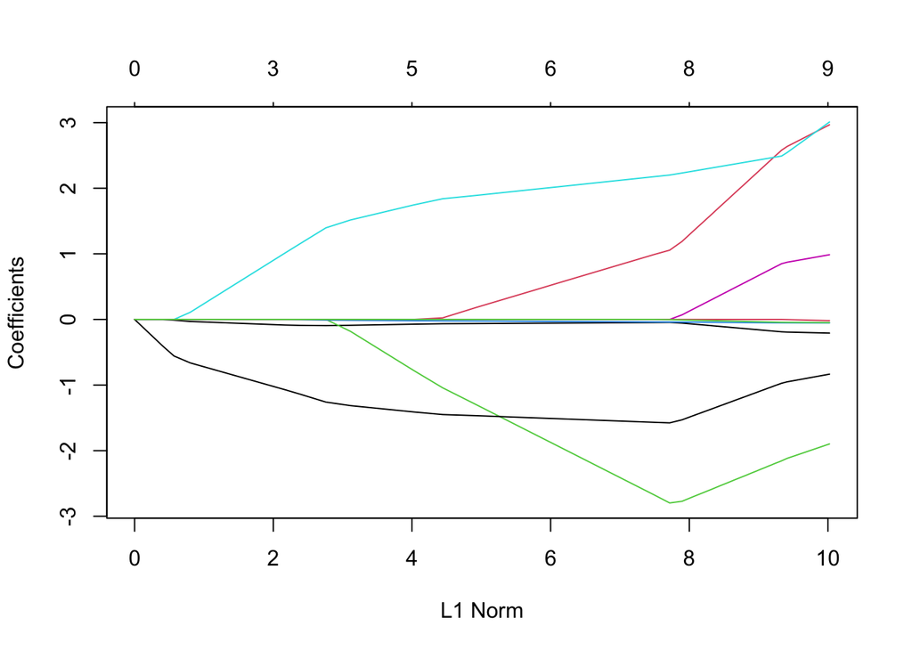

```r
plot(fit)
```

#### Print summary

A summary of the glmnet path at each step is displayed if we just enter the object name or use the print function:

```r
print(fit)
```

```
##
## Call:  glmnet(x = cereal[, c(2:15)], y = cereal$rating)
##
##    Df  %Dev  Lambda
## 1   0  0.00 10.6000
## 2   1  9.80  9.6600
## 3   1 17.93  8.8020
## 4   2 25.49  8.0200
## 5   3 34.10  7.3070
## 6   3 42.71  6.6580
## 7   3 49.86  6.0670
## 8   3 55.80  5.5280
## 9   3 60.73  5.0370
## 10  3 64.83  4.5890
## 11  4 68.85  4.1820
```

[output cut: 44 more lines]

#### Results for various $\lambda$s

##### Results $\lambda = 8$:

```r
coef(fit, s = 8)
```

```
## 15 x 1 sparse Matrix of class "dgCMatrix"
##                       s1
## (Intercept) 47.792423392
## mfr          .
## type         .
## calories    -0.011761317
## protein      .
## fat          .
## sodium       .
## fiber        0.003044207
## carbo        .
## sugars      -0.559973921
## potass       .
## vitamins     .
## shelf        .
## weight       .
## cups         .
```

##### Results $\lambda = 5$:

```r
coef(fit, s = 5)
```

```
## 15 x 1 sparse Matrix of class "dgCMatrix"
##                     s1
## (Intercept) 56.0524151
## mfr          .
## type         .
## calories    -0.0774744
## protein      .
## fat          .
## sodium       .
## fiber        0.8793123
## carbo        .
## sugars      -1.0110026
## potass       .
## vitamins     .
## shelf        .
## weight       .
## cups         .
```

##### Results $\lambda=3$

```r
coef(fit, s = 3)
```

```
## 15 x 1 sparse Matrix of class "dgCMatrix"
##                      s1
## (Intercept) 60.30274330
## mfr          .
## type         .
## calories    -0.08418212
## protein      .
## fat         -0.36321450
## sodium      -0.01495494
## fiber        1.58588432
## carbo        .
## sugars      -1.34298766
## potass       .
## vitamins     .
## shelf        .
## weight       .
## cups         .
```

##### Results $\lambda=1$

```r
coef(fit, s = 1)
```

```
## 15 x 1 sparse Matrix of class "dgCMatrix"
##                       s1
## (Intercept) 60.130427005
## mfr          .
## type         .
## calories    -0.046209154
## protein      1.015703245
## fat         -2.722382117
## sodium      -0.038508265
## fiber        2.185851454
## carbo        .
## sugars      -1.571279485
## potass       .
## vitamins    -0.001130479
## shelf        .
## weight       .
## cups         .
```